# Structure-aware beta diversity with repdist

Yixuan Yang

9 October 2026

#### Package

repdist 0.99.0

# 1 Why a representation distance

Bray-Curtis, Jaccard and their relatives compare samples through protein *identity*: two proteins are either the same accession or maximally different. Metaproteomes break that assumption. Two communities can carry the same enzymatic function on accessions that never overlap, and an identity-based distance cannot tell that case apart from any other difference — it simply reports the maximum and stops.

`repdist` replaces the identity comparison with a distance in a protein language model’s representation space. Each sample becomes an abundance-weighted distribution over protein embeddings, and two samples are compared by the maximum mean discrepancy (MMD) between those distributions under an RBF kernel. The ground distance is defined for *any* pair of sequences, including proteins with no annotation, no tree position, and no homolog in the other sample.

This vignette runs the whole workflow on real data:

1. **Beta diversity** with the MMD distance and a PERMANOVA in *vegan*.
2. **Structural bins** by Markov clustering of the graph joining proteins with a predicted TM-score of at least 0.7.
3. **Differential abundance** on the bins with *DESeq2*.
4. **Reading the winner**: the functional annotations of the proteins in the most responsive bin.

The [simulation study](https://yixuan39.github.io/repdist/simulation.html) on the package website shows on simulated data exactly when this matters — and when Bray-Curtis cannot see a real difference at all.

```r
library(repdist)
library(ggplot2)
```

# 2 Installation

```r
if (!requireNamespace("BiocManager", quietly = TRUE)) {
    install.packages("BiocManager")
}
BiocManager::install("repdist")
```

# 3 The example dataset

The study is Blakeley-Ruiz *et al.*, *ISME J* **19**(1) wraf048: mouse faecal metaproteomes across six dietary protein sources, quantified by spectral counting. Does dietary protein source restructure the gut metaproteome, and which proteins carry the signal?

```r
d <- readRDS(system.file("extdata", "diet_metaproteome.rds",
    package = "repdist"
))
names(d)
```

```
#> [1] "counts"     "counts_raw" "metadata"   "proteins"   "taxa"
#> [6] "provenance"
```

`counts` was rarefied to even depth on the full protein catalog and then cut to the 2000 most abundant proteins, so the shipped table’s row totals differ — it is **not** itself equal-depth. `sample_mmd()` normalizes each row anyway. `counts_raw` is the same samples and proteins before rarefaction, which is what the differential-abundance step uses — it fits its own per-sample normalization. See `?diet_metaproteome` for every field and the installed `scripts/DATA_PROVENANCE.md` for source, licence and processing.

```r
dim(d$counts)
```

```
#> [1]   99 2000
```

```r
table(d$metadata$diet)
```

```
#>
#> Casein    Egg    Pea   Rice    Soy  Yeast
#>     28     10     11     10     29     11
```

Each mouse contributes several samples, so `subject` is carried through everything below as a blocking factor. The full study is 30,561 proteins; shipped here are the 2000 most abundant after rarefaction, which hold 80% of the total spectral counts. `inst/scripts/prepare_vignette_data.R` in the source repository is the script that made this object.

# 4 Embedding

`embed_proteins()` downloads a protein language model and runs it through a pinned Python environment managed by *basilisk*; you do not manage Python packages yourself. Every sequence is embedded whole and every sequence comes back, in input order — nothing is truncated, subset, or silently dropped. Because the default model is several gigabytes, the embeddings here are precomputed; on your own data this is the one call that needs the model. Embeddings made with the `tmvec` command-line tool (https://github.com/valentynbez/tmvec) are read with `read_embeddings()` instead:

```r
x <- embed_proteins("proteins.fasta") # default model: "tmvec"
x <- read_embeddings("db/proteins.npz", seqs = "proteins.fasta")
```

Either way the result is an `AAStringSet`: the sequences, named by accession, with one embedding row per protein in `mcols(x)$embedding`. The shipped data holds the same object.

```r
x <- d$proteins
x
```

```
#> AAStringSet object of length 2000:
#>        width seq                                            names
#>    [1]  1337 MRKTFLKVSLLAVLGLGMSASF...WGQNVLLGYATITVQPTLQGK AB20-1_Cage1_bin....
#>    [2]   336 MIKVGINGFGRIGRFVFRAAMK...NEIGYSNKVLDLIAHMASVNA BT_lowQ_bin.43_Ca...
#>    [3]  1665 MRNLKKILALVLALVMSLSLMA...KKAESTTTPTVDANTSKDQEA AB54-8_Cage2_bin....
#>    [4]   335 MTKIGINGFGRIGRFVFRASTK...NEIGYSNKVLDLIAHMKKYNG amb_Cage1_bin.50_...
#>    [5]   338 MTVKIGINGFGRIGRLAFRRIM...YDNEYSFTCQMVRTLLKFATL AB1-1_Cage4_bin.6...
#>    ...   ... ...
#> [1996]  1476 MYVTSNNREINANINRRVINAA...KGTKTTFTFTTAGGWGPGAVT Unbin_Cage2_HKMOJ...
#> [1997]   382 MNIHEYQGKAIFRSMGVAVPEG...IEPAATMAEGAQKIVKLVKEA Unbin_Cage2_HKMOJ...
#> [1998]   348 MKRITIYDVAKEADVSLATVSR...PMIREKDKTGETEKVTFEAVS AB112-1_Cage1_bin...
#> [1999]   564 MNVKKYLKLGGAALMLGMSSCV...LFPIPSAVLNSQPDFKQNPGY AB16-0_co.bin.106...
#> [2000]    79 MADIANRVKEIIVDKLGVDENE...KAEGIKTVADAIAYIEANAAE AB20-1_Cage1_bin....
```

```r
dim(S4Vectors::mcols(x)$embedding)
```

```
#> [1] 2000  512
```

`known_models()` lists the registered models, each with a `description` of what its embedding measures. Those keys are the whole of what `model` accepts: the pinned environment fixes which architectures load at all, so an arbitrary HuggingFace repo is rejected rather than embedded on a stack nobody has checked it against. TM-Vec heads are the reason the scale is interpretable: the head was trained to regress the TM-score of protein pairs, so cosine similarity between two TM-Vec embeddings *is* a predicted TM-score. When structural similarity is not the question, the `esm2-*` models embed general sequence features instead — at the cost of that calibration.

Other trained heads exist, and some of them cluster proteins better than a TM-score head does. They are not the default here because their distance has no referent outside the model: it means similarity as that model was trained to define it, so a threshold on it cannot be read as anything in particular. A predicted TM-score can.

```r
names(known_models())
```

```
#> [1] "tmvec"     "tmvec-300" "esm2-8m"   "esm2-150m" "esm2-650m"
```

# 5 The protein similarity graph

`protein_similarity()` builds the protein-by-protein similarity – for TM-Vec, the predicted TM-score – that binning reads. Pairs below `min_sim` are set to 0, and so are pairs whose local alignment (BLOSUM62 unless `substitutionMatrix` says otherwise) covers less than `min_coverage` (default 0.5) of either sequence, so two proteins sharing only one domain are not joined. Only pairs above `min_sim` are aligned; `n_cores` spreads the alignments over several cores.

Build it once with no gates, to see every predicted TM-score, and once with the gates you bin at:

```r
S_all <- protein_similarity(x, min_sim = 0, min_coverage = 0) # every pair
S <- protein_similarity(x, min_sim = 0.7) # TM >= 0.7, half of both covered
```

`sample_mmd()` does not take this matrix: MMD needs a positive-semi-definite kernel, which the Gaussian RBF gives on Euclidean distances but not on `1 - cosine`, so it builds the Euclidean distance from the embeddings itself. On the unit-norm rows `embed_proteins()` returns the two are monotone transforms of each other (`||a - b|| = sqrt(2 * (1 - cos))`) and rank protein pairs identically, so nothing is given up.

```r
pairs <- S_all[upper.tri(S_all)]
c(
    median_predicted_TM = round(median(pairs), 3),
    pairs_above_0.7 = sum(pairs >= 0.7)
)
```

```
#> median_predicted_TM     pairs_above_0.7
#>               0.341           27418.000
```

# 6 Step 1: beta diversity

Two distances over the same rarefied counts. Bray-Curtis is the protein-level baseline: it can only ask whether two samples hold the *same accession*. MMD asks how far apart the proteins they hold actually are.

```r
D <- list(
    `Bray-Curtis` = vegan::vegdist(d$counts, "bray"),
    `MMD`         = sample_mmd(d$counts, x)
)
```

`sample_mmd()` treats each sample as an abundance-weighted distribution over embeddings and returns the maximum mean discrepancy between them. Both are `dist` objects, so they drop straight into *vegan*.

Both are also abundance-weighted, so both inherit some dependence on how many proteins a sample carries — MMD doubly so, since a sample’s own within-sample dispersion enters its self-term. One line before reading any $R^2$: how much of each distance richness alone explains.

```r
rich <- vegan::specnumber(d$counts)
round(vapply(D, function(x) cor(rich, rowMeans(as.matrix(x))), numeric(1)), 2)
```

```
#> Bray-Curtis         MMD
#>       -0.92       -0.82
```

Richness still spans 6.6-fold after rarefaction and tracks both distances, MMD slightly *less* than the protein-identity baseline. That baseline is the thing to check against: a representation distance more richness-coupled than Bray-Curtis would be the first thing to suspect of tracking depth rather than structure.

## 6.1 PERMANOVA

Amount of protein, sex and age stay in the model as covariates and diet goes last, so its reported $R^2$ is what survives *after* them — the conservative reading. Permutations are blocked within mouse.

```r
md <- d$metadata
md$subject <- factor(md$subject)
perm <- permute::how(blocks = md$subject, nperm = 999)

res <- do.call(rbind, lapply(names(D), function(n) {
    set.seed(1)
    a <- vegan::adonis2(D[[n]] ~ dose + sex + age_week + diet,
        data = md,
        by = "terms", permutations = perm
    )
    data.frame(
        distance = n, R2 = round(a["diet", "R2"], 3),
        F = round(a["diet", "F"], 2), p = a["diet", "Pr(>F)"]
    )
}))
knitr::kable(res, row.names = FALSE)
```

| distance | R2 | F | p |
| --- | --- | --- | --- |
| Bray-Curtis | 0.275 | 10.37 | 0.001 |
| MMD | 0.307 | 11.45 | 0.001 |

Both find dietary protein source highly significant. That is worth being precise about: these are cage-housed lab mice searched against one protein database, so samples really do share accessions, and accession identity is something Bray-Curtis can read directly. The representation distance is not rescuing a failed analysis here — it is being checked against a case where the conventional method already works, and it agrees. The simulation study on the package website shows the case where only one of them survives.

## 6.2 Ordination

PCoA on each distance, one panel each, coloured by diet. The percentage in each panel heading is that axis’s share of the total variation, computed per distance because each one has its own eigenvalues.

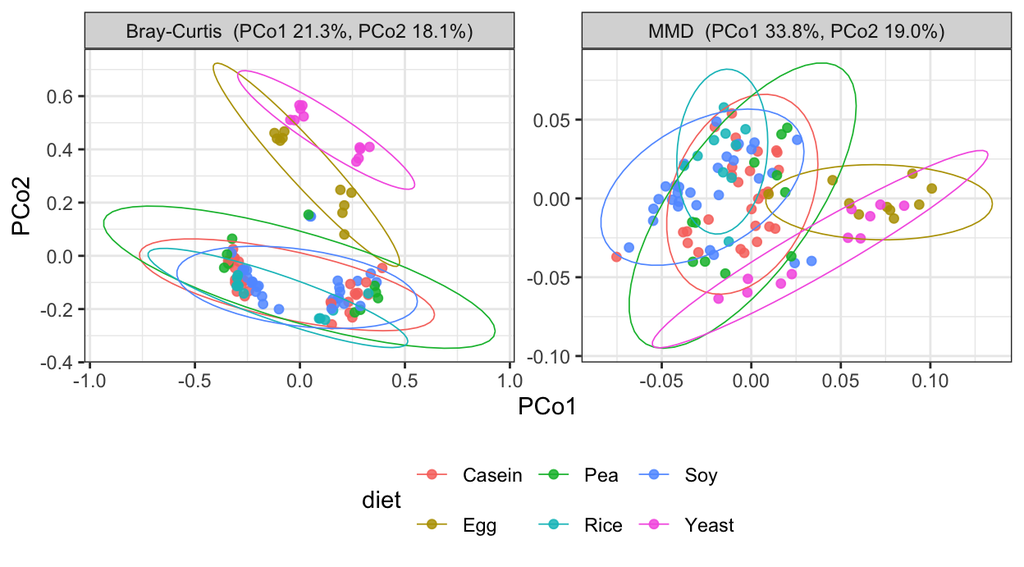

```r
ord <- do.call(rbind, lapply(names(D), function(n) {
    e <- cmdscale(D[[n]], k = 2, eig = TRUE)
    rel <- 100 * e$eig / sum(e$eig[e$eig > 0]) # negative eigenvalues excluded
    data.frame(
        Axis1 = e$points[, 1], Axis2 = e$points[, 2],
        diet = md[rownames(e$points), "diet"],
        panel = sprintf("%s  (PCo1 %.1f%%, PCo2 %.1f%%)", n, rel[1], rel[2])
    )
}))

ggplot(ord, aes(Axis1, Axis2, colour = diet)) +
    geom_point(size = 1.6, alpha = 0.85) +
    stat_ellipse(type = "t", linewidth = 0.3) +
    facet_wrap(~panel, scales = "free") +
    labs(x = "PCo1", y = "PCo2", colour = "diet") +
    theme_bw() +
    theme(legend.position = "bottom")
```

# 7 Step 2: structural bins at TM-score 0.7

PERMANOVA says diet structures the community; it says nothing about which proteins carry it. Testing 2000 proteins one at a time would pay a multiple-testing price on units that are not independent — homologous proteins are the same signal counted repeatedly.

`bin_proteins()` collapses them into bins: every nonzero pair of `S`, a predicted TM-score of at least 0.7 with half of both sequences aligned, is an edge, and Markov clustering (MCL) at inflation 2 splits the graph. The 0.7 sits above TM-score’s conventional same-fold boundary of 0.5, but it is an edge floor, not an all-pairs guarantee: a bin can hold pairs below it, joined through shared neighbours.

```r
b <- bin_proteins(S, inflation = 2)
b$graph
```

```
#>          proteins             edges          isolated        components
#>              2000             20193               279               473
#> largest_component
#>               146
```

`b$graph` describes the graph MCL split. Isolated proteins have no edge at this floor and become singleton bins; a largest component holding most of the proteins would mean the floor is too low to separate anything before MCL starts.

`plot_tsne()` maps the embeddings in two dimensions, here with the 12 largest bins coloured. A bin should sit in one neighbourhood; one split across two islands, as a couple are here, is worth a look with `plot_bin_similarity()`. t-SNE keeps neighbours together but not the distances between groups, so read it for compactness, not for how far apart bins sit.

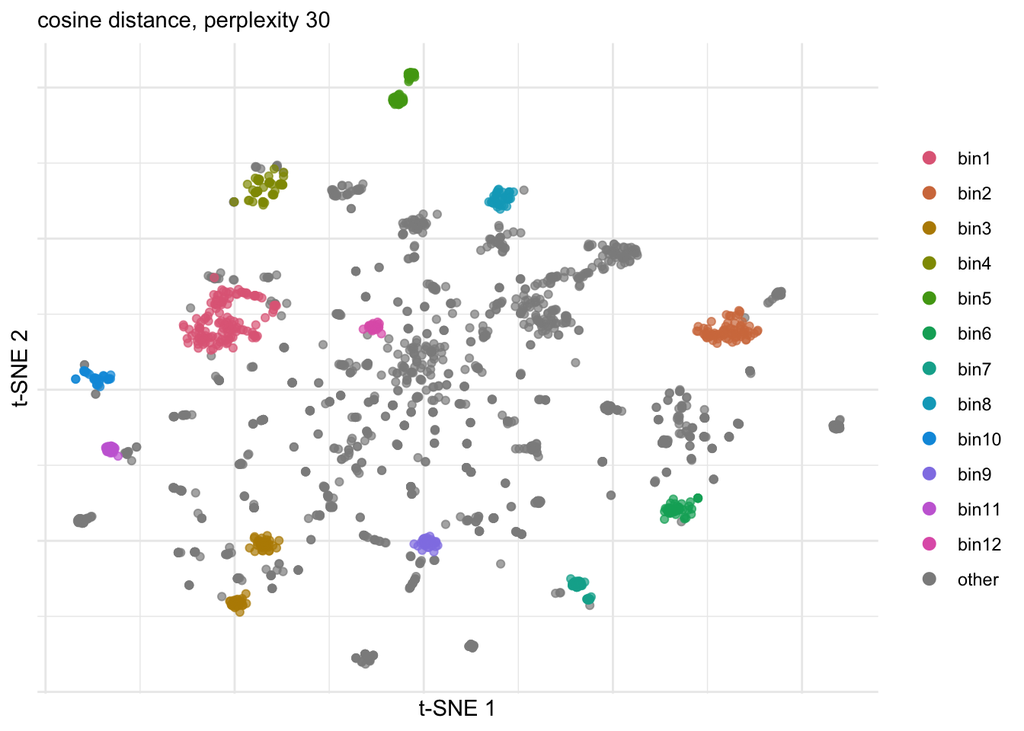

```r
set.seed(1)
plot_tsne(x, color = b$membership)
```

Rolling the unrarefied counts up to bin level is one `bin_glom()` call:

```r
binned <- bin_glom(d$counts_raw, b)
c(proteins = ncol(d$counts_raw), bins = ncol(binned))
```

```
#> proteins     bins
#>     2000      512
```

```r
sizes <- lengths(b$clusters)
table(cut(sizes, c(0, 1, 2, 5, 10, Inf),
    labels = c("1", "2", "3-5", "6-10", ">10")
))
```

```
#>
#>    1    2  3-5 6-10  >10
#>  279   80   84   37   32
```

279 of the 2000 proteins have no structural relative at this floor and stay in a bin of their own. The rest fall into 233 multi-member bins, which is where the collapse buys something: the number of things to test drops by a factor of 3.9, and each surviving unit is a structural group rather than an accession.

# 8 Step 3: differential abundance with DESeq2

*DESeq2* fits a negative-binomial model per bin on the **unrarefied** counts — its size factors are the model-based counterpart to rarefaction. The design is paired: `subject` enters as a fixed blocking factor, absorbing sex, cage, and every other between-mouse difference, and diet is tested *within* mice. Size factors use the `"poscounts"` estimator because, as in most metaproteomes, few bins are observed in every sample.

Diet has six levels, so “the diet effect” on a bin is a likelihood-ratio test against the model without diet — the counterpart to `adonis2`’s `by = "terms"`, not a single contrast.

```r
dds <- DESeq2::DESeqDataSetFromMatrix(t(binned), md,
    design = ~ subject + diet
)
dds <- DESeq2::DESeq(dds,
    test = "LRT", reduced = ~subject,
    sfType = "poscounts", quiet = TRUE
)
res_lrt <- DESeq2::results(dds)

c(
    bins_tested = nrow(res_lrt),
    diet_significant = sum(res_lrt$padj <= 0.05, na.rm = TRUE)
)
```

```
#>      bins_tested diet_significant
#>              512              398
```

Nothing about the bins is DESeq2-specific — they are ordinary count columns, so a compositional model such as LinDA or ALDEx2 drops in the same way.

The LRT has no size to it — no single number is “the” effect when diet has five contrasts against the Casein reference. So each significant bin is given, as its effect size, the largest fold change it shows against Casein on any diet. Two refinements matter here. `nbinomWaldTest()` re-uses the dispersions already fitted to give each contrast its own test, which the volcano below needs; and `lfcShrink()` pulls fold changes toward zero in proportion to how little supports them, so a bin seen in a handful of samples cannot post an enormous log-ratio on almost no evidence.

```r
lev <- setdiff(levels(md$diet), "Casein")
ddsw <- DESeq2::nbinomWaldTest(dds, quiet = TRUE)
shrunk <- lapply(lev, function(l) {
    DESeq2::lfcShrink(ddsw,
        coef = paste0("diet_", l, "_vs_Casein"),
        type = "normal", quiet = TRUE
    )
})
names(shrunk) <- lev
fc <- vapply(shrunk, function(o) o$log2FoldChange, numeric(nrow(res_lrt)))
rownames(fc) <- rownames(res_lrt)

sig <- rownames(res_lrt)[!is.na(res_lrt$padj) & res_lrt$padj <= 0.05]
top <- data.frame(
    bin     = sig,
    members = sizes[sig],
    padj    = formatC(res_lrt[sig, "padj"], digits = 2, format = "e"),
    diet    = lev[apply(abs(fc[sig, ]), 1, which.max)],
    log2FC  = round(fc[cbind(sig, lev[apply(abs(fc[sig, ]), 1, which.max)])], 2)
)
top <- top[order(-abs(top$log2FC)), ]
knitr::kable(head(top, 8), row.names = FALSE)
```

| bin | members | padj | diet | log2FC |
| --- | --- | --- | --- | --- |
| bin156 | 2 | 1.53e-19 | Yeast | -8.00 |
| bin104 | 4 | 1.64e-30 | Yeast | -7.97 |
| bin102 | 4 | 1.01e-02 | Yeast | 7.92 |
| bin95 | 4 | 1.84e-22 | Yeast | -7.76 |
| bin241 | 1 | 1.32e-65 | Yeast | 7.31 |
| bin287 | 1 | 2.87e-03 | Yeast | 7.24 |
| bin222 | 2 | 2.11e-02 | Yeast | 7.20 |
| bin108 | 4 | 1.30e-16 | Yeast | -7.09 |

A volcano plot needs one effect size per point, so the five diet-vs-Casein contrasts are shown separately: one panel per diet, shrunken log2 fold change on the x-axis, each point one bin, red where that specific contrast rejects at `padj <= 0.05`.

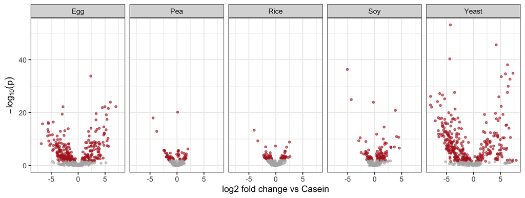

```r
volc <- do.call(rbind, lapply(lev, function(l) {
    o <- shrunk[[l]]
    data.frame(
        bin = rownames(o), diet = l, log2FoldChange = o$log2FoldChange,
        pvalue = o$pvalue, reject = !is.na(o$padj) & o$padj <= 0.05
    )
}))

ggplot(volc, aes(log2FoldChange, -log10(pvalue), color = reject)) +
    geom_point(alpha = 0.6, size = 1) +
    facet_wrap(~diet, nrow = 1) +
    scale_color_manual(
        values = c(`FALSE` = "grey70", `TRUE` = "firebrick"),
        guide = "none"
    ) +
    labs(x = "log2 fold change vs Casein", y = expression(-log[10](p))) +
    theme_bw()
```

# 9 Step 4: the three most responsive bins, read functionally

The very top of that table is telling in its own right: several of the most responsive bins contain only proteins with **no database annotation at all** — groups a lineage- or profile-based method cannot form, held together here by structure alone. But a bin with no annotations cannot demonstrate what the annotations of a bin look like, so take the three most responsive bins whose members carry them:

```r
n_ann <- vapply(
    b$clusters[top$bin],
    function(m) sum(!is.na(d$taxa[m, "annotation"])), integer(1)
)
picks <- head(top[top$members > 1 & n_ann >= 2, ], 3)
knitr::kable(picks, row.names = FALSE)
```

| bin | members | padj | diet | log2FC |
| --- | --- | --- | --- | --- |
| bin104 | 4 | 1.64e-30 | Yeast | -7.97 |
| bin133 | 3 | 1.84e-14 | Yeast | -6.52 |
| bin141 | 3 | 3.00e-08 | Yeast | -6.51 |

Their members, with the counts that produced those fold changes:

```r
info <- do.call(rbind, lapply(seq_len(nrow(picks)), function(i) {
    m <- b$clusters[[picks$bin[i]]]
    data.frame(
        bin         = picks$bin[i],
        genus       = d$taxa[m, "genus"],
        annotation  = substr(d$taxa[m, "annotation"], 1, 52),
        mean_Casein = round(colMeans(
            d$counts_raw[md$diet == "Casein", m, drop = FALSE]
        ), 1),
        mean_top = round(colMeans(
            d$counts_raw[md$diet == picks$diet[i], m, drop = FALSE]
        ), 1)
    )
}))
knitr::kable(info, row.names = FALSE)
```

| bin | genus | annotation | mean_Casein | mean_top |
| --- | --- | --- | --- | --- |
| bin104 | 14-2 | Endo-alpha-N-acetylgalactosaminidase | 4.8 | 0.0 |
| bin104 | NA | Endo-alpha-N-acetylgalactosaminidase | 18.2 | 0.0 |
| bin104 | 1XD42-69 | Endo-alpha-N-acetylgalactosaminidase | 2.4 | 0.0 |
| bin104 | UBA9475 | Endo-alpha-N-acetylgalactosaminidase | 0.6 | 0.0 |
| bin133 | Staphylococcus | Dihydrolipoyl dehydrogenase | 10.5 | 0.0 |
| bin133 | Staphylococcus | NA | 4.2 | 0.0 |
| bin133 | Dorea | thioredoxin reductase | 2.5 | 0.3 |
| bin141 | NA | Carbon monoxide dehydrogenase | 3.0 | 0.0 |
| bin141 | NA | Carbon monoxide dehydrogenase | 6.2 | 0.0 |
| bin141 | NA | Carbon monoxide dehydrogenase | 2.8 | 0.0 |

Read the annotation column one bin at a time. In **bin104** all four members carry the same call, *endo-alpha-N-acetylgalactosaminidase* — one mucin-O-glycan-cleaving activity supplied by four distinct accessions from four different genome bins. **bin133** is the caution: a dihydrolipoyl dehydrogenase and a thioredoxin reductase are both flavoprotein disulfide reductases, built on the same FAD- and NAD(P)H-binding domains but doing different jobs, and the third member has no annotation at all. **bin141** agrees again: three carbon monoxide dehydrogenases, none from a named genus.

That is the workflow’s point, and its limit. At the protein level each of these is several weak tests on units that are not independent; as a bin it is one unit, one test, and one structural reading — a shared activity where the annotations agree, a shared family where they do not — including for the members with no annotation, which inherit a specific, checkable hypothesis from their bin-mates instead of silence. All three fall on the same diet and in the same direction, which is a property of that diet’s proteome rather than of any one accession.

MCL makes no all-pairs promise: members are joined through the graph, so a pair inside a bin need not be an edge. `plot_bin_similarity()` colours every pair by its predicted TM-score and crosses out every pair that is not an edge, so it shows whether a bin is one tight group or two sub-groups joined through a few edges. A crossed pair above 0.7 failed the coverage gate:

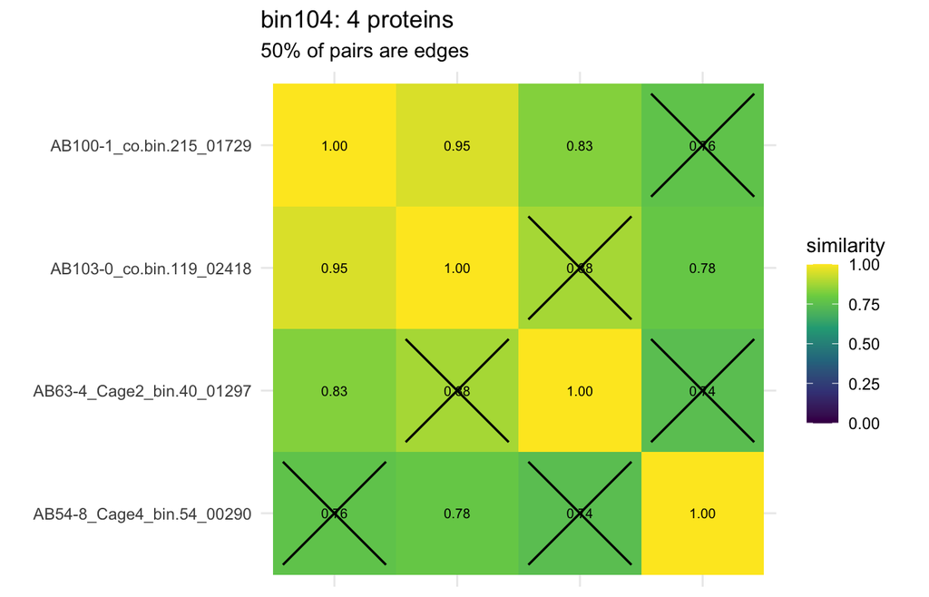

```r
plot_bin_similarity(b, picks$bin[1], S, x)
```

# 10 Practical notes

**Sampling depth.** `sample_mmd()` normalizes each row, which removes total-count scaling but not the effect of depth on which proteins were seen at all; check depth and richness as confounders, and rarefy with `vegan::rrarefy()` if you want them off the table, at the cost of discarded counts. The differential-abundance model wants the opposite — raw counts, with depth handled by its size factors.

**Memory.** `protein_similarity()` and `sample_mmd()` hold protein-by-protein matrices, so bin the *identified* subset of a catalog, never a whole search database.

**Bandwidth.** `sample_mmd()` returns the bandwidth it used as `attr(, "sigma")`; pass it back to compare across studies. With the default the kernel is nearly linear in TM-score, so the distance is close to the euclidean distance between abundance-weighted mean embeddings, and on this data that is also where separation peaks. Checking that is one line: the largest exponent the kernel ever sees, `(1 - min(S_all)) / attr(D$MMD, "sigma")^2` (the euclidean `||a - b||^2 / (2 sigma^2)` on unit-norm rows), is 0.67 here, so `exp()` never leaves its near-linear stretch. A much larger value means the kernel is saturating and only near-identical proteins still count.

The full analysis runs this same workflow on every protein that survives rarefaction and a 3,000aa ceiling, rather than the 2,000-protein package subset. That ceiling is a choice about TM-Vec’s training range, not something `repdist` imposes – `embed_proteins()` embeds every sequence whole and no function here takes a maximum length. It is published at https://yixuan39.github.io/repdist/, with its source on the `gh-pages` branch.

# 11 References

# Appendix

- Blakeley-Ruiz et al. (2025). Dietary protein source alters gut microbiota composition and function. https://doi.org/10.1093/ismejo/wraf048.
- Hamamsy et al. (2024). Protein remote homology detection and structural alignment using deep learning. https://doi.org/10.1038/s41587-023-01917-2.
- Gretton et al. (2012). A Kernel Two-Sample Test. https://jmlr.org/papers/v13/gretton12a.html.